# The Effect on Vitamin C on Guinea Pigs’ Tooth Growth

Giulio Mario Martena

6/4/2020

## Overview

The general goal of this analysis is to analyze the `ToothGrowth` dataset, part of the `datasets` library preincluded in R. From the documentation of the dataset, we learn that among 60 guinea pigs, *each animal received one of three dose levels of vitamin C (0.5, 1, and 2 mg/day) by one of two delivery methods, **orange juice** or **ascorbic acid** (a form of vitamin C and coded as VC)*.

```r
data("ToothGrowth")
ToothGrowth$dose <- factor(ToothGrowth$dose)
ToothGrowth<-as_tibble(ToothGrowth);print(ToothGrowth)
```

```
## # A tibble: 60 x 3
##      len supp  dose
##    <dbl> <fct> <fct>
##  1   4.2 VC    0.5
##  2  11.5 VC    0.5
##  3   7.3 VC    0.5
##  4   5.8 VC    0.5
##  5   6.4 VC    0.5
##  6  10   VC    0.5
##  7  11.2 VC    0.5
##  8  11.2 VC    0.5
##  9   5.2 VC    0.5
## 10   7   VC    0.5
## # … with 50 more rows
```

## Hypothesis Testing

First of all, I wonder if mean from the tooth growth is the same **globally** and **divided by dosage**.

### Hypothesis 1: no dosage separation

$$H_0: \mu_{OJ} = \mu_{VC}$$
$$H_1: \mu_{OJ} > \mu_{VC}$$

```r
h1<-t.test(len ~ supp, ToothGrowth, paired = FALSE, var.equal = TRUE)
h1$conf.int; h1$p.value
```

```
## [1] -0.1670064  7.5670064
## attr(,"conf.level")
## [1] 0.95
```

```
## [1] 0.06039337
```

The p-value >0.05 and C.I. includes 0. The $H_0$ cannot be rejected. So orange juice & ascorbic acid seem to deliver the same tooth growth without factoring dose levels.

**Hypothesis 2**:

- $H_0$: Mean tooth growth from orange juice is same as ascorbic acid for the dose level of 0.5 mg/day.
- $H_1$: Mean tooth growth from orange juice is higher for the dose level of 0.5 mg/day.

```r
h2<-t.test(len ~ supp, data = filter(ToothGrowth, dose == 0.5), paired = F, var.equal = T)
h2$conf.int; h2$p.value
```

```
## [1] 1.770262 8.729738
## attr(,"conf.level")
## [1] 0.95
```

```
## [1] 0.005303661
```

The p-value is <0.05. The C.I. does not include 0. The $H_0$ is rejected. So 0.5 mg/day dosage of orange juice seems to deliver more tooth growth than ascorbic acid.

**Hypothesis 3**:

- $H_0$: Mean tooth growth from orange juice is same as ascorbic acid for the dose level of 1 mg/day.
- $H_1$: Mean tooth growth from orange juice is higher for the dose level of 1 mg/day.

```r
h3<-t.test(len ~ supp, data = filter(ToothGrowth, dose == 1), paired = F, var.equal = T)
h3$conf.int; h3$p.value
```

```
## [1] 2.840692 9.019308
## attr(,"conf.level")
## [1] 0.95
```

```
## [1] 0.0007807262
```

The p-value is <0.05 and the C.I. does not include 0. The $H_0$ is rejected. So 1 mg/day dosage of orange juice seems to deliver more tooth growth than ascorbic acid.

**Hypothesis 4**:

- $H_0$: Mean tooth growth from orange juice is same as ascorbic acid for the dose level of 2 mg/day.
- $H_1$: Mean tooth growth from orange juice is higher for the dose level of 2 mg/day.

```r
h4<-t.test(len ~ supp, data = filter(ToothGrowth, dose == 2), paired = F, var.equal = T)
h4$conf.int; h4$p.value
```

```
## [1] -3.722999  3.562999
## attr(,"conf.level")
## [1] 0.95
```

```
## [1] 0.9637098
```

The p-value is >0.05 and the C.I. does include 0. $H_0$ cannot be rejected. So 2 mg/day dosage of orange juice seems to deliver same tooth growth as ascorbic acid.

**Hypothesis 5**:

- $H_0$: Mean tooth growth from ascorbic acid (2 mg/day) is same as orange juice (1 mg/day).
- $H_1$: Mean tooth growth from ascorbic acid (2 mg/day) is higher than orange juice (1 mg/day).

```r
temp1 <- rbind(filter(ToothGrowth, (dose == 1) & (supp =="OJ")),
               filter(ToothGrowth, (dose == 2) & (supp =="VC")))
h5<-t.test(len ~ supp, temp1, paired = F, var.equal = T)
h5$conf.int; h5$p.value
```

```
## [1] -7.552325  0.672325
## attr(,"conf.level")
## [1] 0.95
```

```
## [1] 0.09583711
```

The p-value is >0.05 and the C.I. does include 0. The $H_0$ cannot be rejected. 2 mg/day of ascorbic acid seems to deliver same tooth growth as 1 mg/day of orange juice.

**Hypothesis 6**:

- $H_0$: Mean tooth growth from orange juice (2 mg/day) is same as orange juice (1 mg/day).
- $H_1$: Mean tooth growth from orange juice (2 mg/day) is higher than orange juice (1 mg/day).

```r
temp2 <- rbind(filter(ToothGrowth, (dose == 1) & (supp =="OJ")),
               filter(ToothGrowth, (dose == 2) & (supp =="OJ")))
h6<-t.test(len ~ dose, temp2, paired = F, var.equal = T)
h6$conf.int; h6$p.value
```

```
## [1] -6.5005017 -0.2194983
## attr(,"conf.level")
## [1] 0.95
```

```
## [1] 0.0373628
```

The p-value is <0.05 and the C.I. does not include 0. $H_0$ is rejected. So 2 mg/day of orange juice seems to deliver higher tooth growth than 1 mg/day.

## Conclusion

Increase in the dose levels seem to increase the tooth growth. Orange juice is more effective than ascorbic acid for tooth growth when the dosage is 0.5 and 1 mg/day. Both types of supplements are equally as effective when the dose is 2 mg/day. I’ve assumed there’s a common variance in the guinea pigs population (var.equal=TRUE) and that they’ve used 6 different settings of 10 guinea pigs for the experiment (paired=FALSE) so as not to get biased by an earlier test.

## Appendix

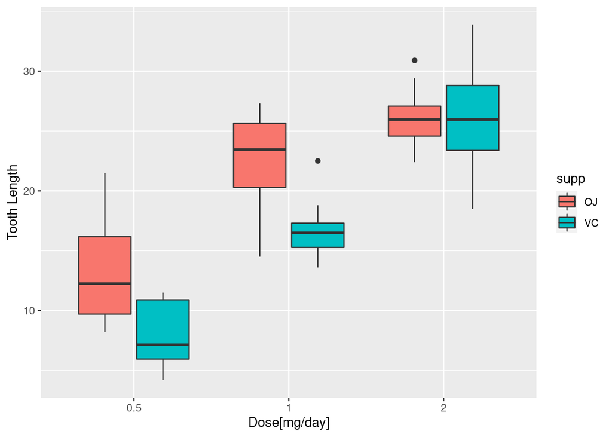

Fig.1: Tooth Length vs Supplement and Dose Levels

**Plot 3**:

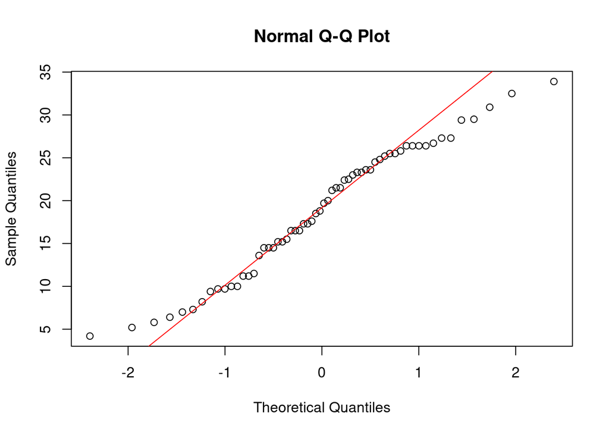

```r
qqnorm(ToothGrowth$len); qqline(ToothGrowth$len, col = 2)
```